# Chapter5.Rmd

JL

30 11 2021

# Chapter 5: Dimensionality Reduction Techniques

```r
library("GGally")
library("dplyr")
human <- read.csv("D:/Johanna/Documents/Väitöskirja/Jatko-opinnot/Open data science/Rstudio_Git/IODS-project/data/human.csv", header=TRUE, sep= " ")

str(human)
```

```
## 'data.frame':    155 obs. of  8 variables:
##  $ eduratio: num  1.007 0.997 0.983 0.989 0.969 ...
##  $ labratio: num  0.891 0.819 0.825 0.884 0.829 ...
##  $ lifexp  : num  81.6 82.4 83 80.2 81.6 80.9 80.9 79.1 82 81.8 ...
##  $ expedu  : num  17.5 20.2 15.8 18.7 17.9 16.5 18.6 16.5 15.9 19.2 ...
##  $ gni     : int  64992 42261 56431 44025 45435 43919 39568 52947 42155 32689 ...
##  $ matmor  : int  4 6 6 5 6 7 9 28 11 8 ...
##  $ adobirth: num  7.8 12.1 1.9 5.1 6.2 3.8 8.2 31 14.5 25.3 ...
##  $ parlia  : num  39.6 30.5 28.5 38 36.9 36.9 19.9 19.4 28.2 31.4 ...
```

```r
summary(human)
```

```
##     eduratio         labratio          lifexp          expedu
##  Min.   :0.1717   Min.   :0.1857   Min.   :49.00   Min.   : 5.40
##  1st Qu.:0.7264   1st Qu.:0.5984   1st Qu.:66.30   1st Qu.:11.25
##  Median :0.9375   Median :0.7535   Median :74.20   Median :13.50
##  Mean   :0.8529   Mean   :0.7074   Mean   :71.65   Mean   :13.18
##  3rd Qu.:0.9968   3rd Qu.:0.8535   3rd Qu.:77.25   3rd Qu.:15.20
##  Max.   :1.4967   Max.   :1.0380   Max.   :83.50   Max.   :20.20
##       gni             matmor          adobirth          parlia
##  Min.   :   581   Min.   :   1.0   Min.   :  0.60   Min.   : 0.00
##  1st Qu.:  4198   1st Qu.:  11.5   1st Qu.: 12.65   1st Qu.:12.40
##  Median : 12040   Median :  49.0   Median : 33.60   Median :19.30
##  Mean   : 17628   Mean   : 149.1   Mean   : 47.16   Mean   :20.91
##  3rd Qu.: 24512   3rd Qu.: 190.0   3rd Qu.: 71.95   3rd Qu.:27.95
##  Max.   :123124   Max.   :1100.0   Max.   :204.80   Max.   :57.50
```

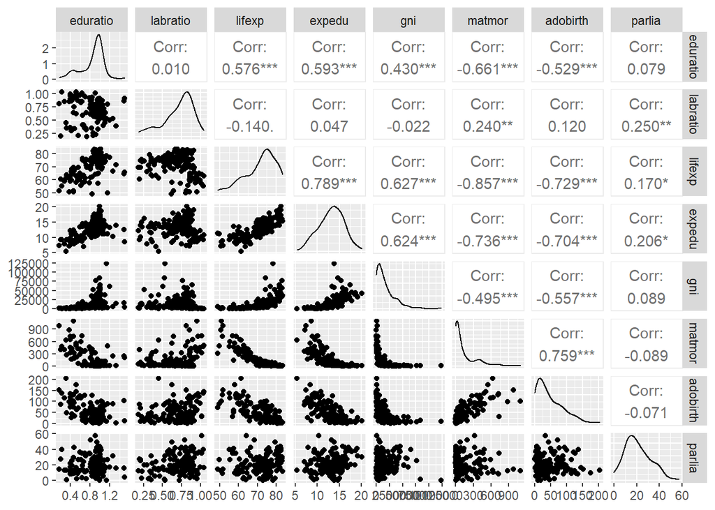

```r
ggpairs(human)
```

The human data includes 155 observations on 8 variables.

CORRELATIONS: Many of the variables correlate moderately of strongly with each other. The strongest negative correlations that are also statistically significant, are found between life expectancy (lifexp) and maternal mortality (matmor) (r = -0.86), life expectancy (lifexp) and adolescent birth rate (adobirth) (r = -0.73), maternal mortality (matmor) and expected years of education (expedu) (r = -0.74), and expected years of education (expedu) and adolescent birth rate (adobirth) (r = -0.70). The ratio of Female and Male populations with secondary education (eduratio) correlates negatively with maternal mortality (matmor) (r = -0.66) and adolescent birth rate (adobirth) (r = -0.53) and these correlations are statistically significant. Strongest statistically significant positive correlations are found between expected years of education (expedu) and life expectancy (lifexp) (r = 0.79), and adolescent birth rate (adobirth) and maternal mortality (matmor) (r = 0.76). The ratio of Female and Male populations with secondary education (eduratio) correlates positively and statistically significantly with life expectancy (lifexp) (r = 0.58), expected years of education (expedu) (r = 0.59), and Gross National Income per capita (gni) (r = 0.43). Gross National Income per capita (gni) correlates positively with life expectancy (lifexp) (r = 0.63), and expected years of education (expedu) (r = 0.62) and these correlations are statistically significant.

Next, we will run a principal component analysis on the data and draw a biplot of the results. First, we will run the PCA wihtout standardizing the data. Then, we will standardize the data and run the PCA again.

```r
#PCA with unstandardized data
#principal component analysis (with the SVD method)
pca_human <- prcomp(human)

#Summary of the results
summary(pca_human)
```

```
## Importance of components:
##                              PC1      PC2   PC3   PC4   PC5   PC6    PC7    PC8
## Standard deviation     1.854e+04 185.5219 25.19 11.45 3.766 1.566 0.1912 0.1591
## Proportion of Variance 9.999e-01   0.0001  0.00  0.00 0.000 0.000 0.0000 0.0000
## Cumulative Proportion  9.999e-01   1.0000  1.00  1.00 1.000 1.000 1.0000 1.0000
```

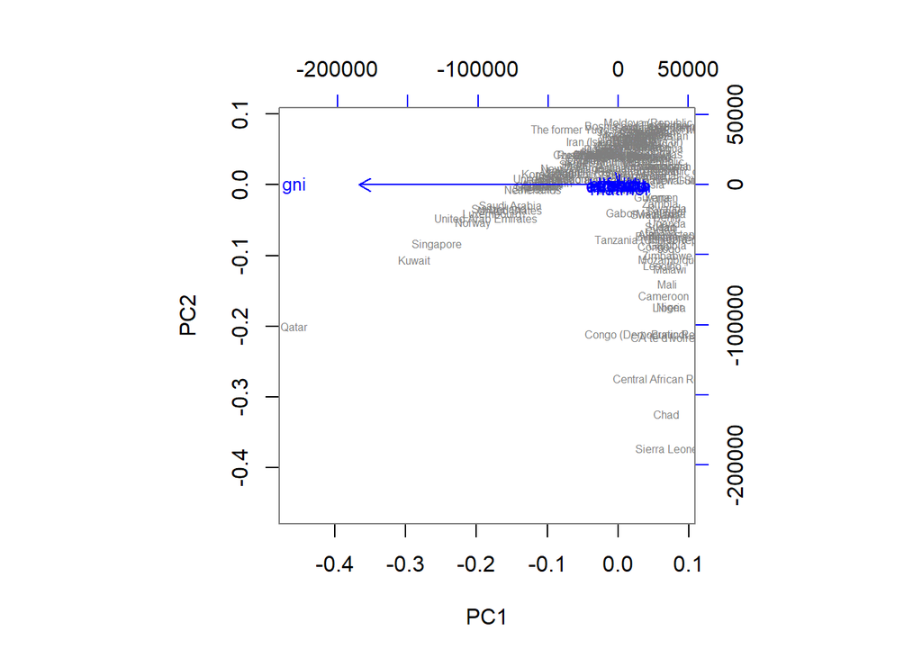

```r
# draw a biplot of the principal component representation and the original variables
biplot(pca_human, choices = 1:2, cex = c(0.5, 0.8), col = c("grey50", "blue"), caption = 'Results on principal components analysis without standardizing the data first')
```

```r
#PCA with standardized data
# standardize the variables
human_std <- scale(human)

# print out summaries of the standardized variables
summary(human_std)
```

```
##     eduratio          labratio           lifexp            expedu
##  Min.   :-2.8189   Min.   :-2.6247   Min.   :-2.7188   Min.   :-2.7378
##  1st Qu.:-0.5233   1st Qu.:-0.5484   1st Qu.:-0.6425   1st Qu.:-0.6782
##  Median : 0.3503   Median : 0.2316   Median : 0.3056   Median : 0.1140
##  Mean   : 0.0000   Mean   : 0.0000   Mean   : 0.0000   Mean   : 0.0000
##  3rd Qu.: 0.5958   3rd Qu.: 0.7350   3rd Qu.: 0.6717   3rd Qu.: 0.7126
##  Max.   : 2.6646   Max.   : 1.6632   Max.   : 1.4218   Max.   : 2.4730
##       gni              matmor           adobirth           parlia
##  Min.   :-0.9193   Min.   :-0.6992   Min.   :-1.1325   Min.   :-1.8203
##  1st Qu.:-0.7243   1st Qu.:-0.6496   1st Qu.:-0.8394   1st Qu.:-0.7409
##  Median :-0.3013   Median :-0.4726   Median :-0.3298   Median :-0.1403
##  Mean   : 0.0000   Mean   : 0.0000   Mean   : 0.0000   Mean   : 0.0000
##  3rd Qu.: 0.3712   3rd Qu.: 0.1932   3rd Qu.: 0.6030   3rd Qu.: 0.6127
##  Max.   : 5.6890   Max.   : 4.4899   Max.   : 3.8344   Max.   : 3.1850
```

```r
# perform principal component analysis (with the SVD method)
pca_human_std <- prcomp(human_std)

#Summary of the results
summary(pca_human_std)
```

```
## Importance of components:
##                           PC1    PC2     PC3     PC4     PC5     PC6     PC7
## Standard deviation     2.0708 1.1397 0.87505 0.77886 0.66196 0.53631 0.45900
## Proportion of Variance 0.5361 0.1624 0.09571 0.07583 0.05477 0.03595 0.02634
## Cumulative Proportion  0.5361 0.6984 0.79413 0.86996 0.92473 0.96069 0.98702
##                            PC8
## Standard deviation     0.32224
## Proportion of Variance 0.01298
## Cumulative Proportion  1.00000
```

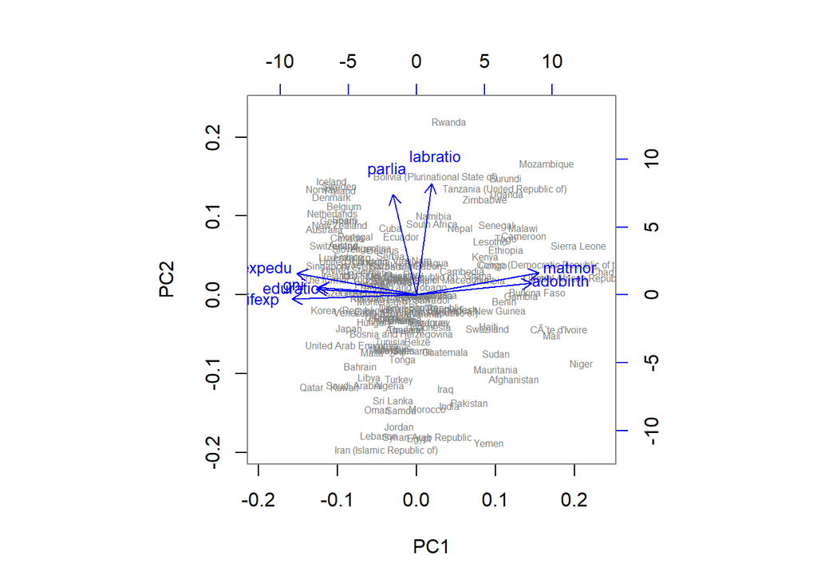

```r
# draw a biplot of the principal component representation and the original variables
biplot(pca_human_std, choices = 1:2, cex = c(0.5, 0.8), col = c("grey50", "blue"), caption = 'Results on principal components analysis with standardized data')
```

(NOTE: For some reason the “caption” argument is not working in the plots!?)

RESULTS OF THE PCA ANALYSES: The result of principal component analysis of unstandardized data is very different from the result of standardized data. The variable “gni” dominates the result of the unstandardized data, probably because it has so much larger range and variation than the other variables. The first component (PC1) explains already 99,99% of the variation in the unstandardized data, and the Gross National Income per capita (gni) seems to be the most relevant variable.

The result of standardized data has also other relevant variables that have an importance on the components. The first two components explain 53.6% (PC1) and 16.2% (PC2) of the variation in the data (together almost 70% of the variation). There are 6 variables that are relevant for the PC1 and 2 variables that are relevant for the PC2: in the high end of PC1 there are countries that have high maternal morbidity and adolescent birth rate. In the low end of PC1 there are countries that have high expected years of education, high life expectancy at birth, high Gross National Income per capita and high ratio of Female and Male populations with secondary education. In the high end of PC 2 there are countries that have high percent of representation in parliament and high ratio of labour force participation of females and males.

INTERPRETATON OF THE FIRST TWO COMPONENTS:

PC1 seems to separate rich and developed countries from poorer and less developed countries, since the variables relevant for this component are maternal morbidity, adolescent birth rate, expected years of education, life expectancy at birth, Gross National Income per capita and ratio of Female and Male populations with secondary education, so that high scores on this component reflect high maternal morbidity and adolescent birth rate, and low values on the other variables, and low scores on this component reflects high expected years of education, life expectancy at birth, Gross National Income per capita and ratio of Female and Male populations with secondary education (meaning that men and women have equally or almost equally secondary education), and low scores on the other two variables. Rich and developed countries score low on PC1 and poorer and less developed countries score higher.

PC2 seems to separate “democratic” countries from more conservative countries. In the high end of this component are countries that have equally or almost equally men and women in the labour force and the parliament represents the people of the country well. In the low end of this component are countries, in which women are not working and the parliament is not representing the people of the country that well.

MULTIPLE CORRESPONDENCE ANALYSIS ON TEA DATA

Next, we will run a multiple correspondence analysis on the tea data, which can be found from the “FactoMineR” package. First, we will load the tea data in and explore its structure.

```r
library("FactoMineR")
data(tea) #Load the tea data
dim(tea) #Dimensions
```

```
## [1] 300  36
```

```r
str(tea) #Structure
```

```
## 'data.frame':    300 obs. of  36 variables:
##  $ breakfast       : Factor w/ 2 levels "breakfast","Not.breakfast": 1 1 2 2 1 2 1 2 1 1 ...
##  $ tea.time        : Factor w/ 2 levels "Not.tea time",..: 1 1 2 1 1 1 2 2 2 1 ...
##  $ evening         : Factor w/ 2 levels "evening","Not.evening": 2 2 1 2 1 2 2 1 2 1 ...
##  $ lunch           : Factor w/ 2 levels "lunch","Not.lunch": 2 2 2 2 2 2 2 2 2 2 ...
##  $ dinner          : Factor w/ 2 levels "dinner","Not.dinner": 2 2 1 1 2 1 2 2 2 2 ...
##  $ always          : Factor w/ 2 levels "always","Not.always": 2 2 2 2 1 2 2 2 2 2 ...
##  $ home            : Factor w/ 2 levels "home","Not.home": 1 1 1 1 1 1 1 1 1 1 ...
##  $ work            : Factor w/ 2 levels "Not.work","work": 1 1 2 1 1 1 1 1 1 1 ...
##  $ tearoom         : Factor w/ 2 levels "Not.tearoom",..: 1 1 1 1 1 1 1 1 1 2 ...
##  $ friends         : Factor w/ 2 levels "friends","Not.friends": 2 2 1 2 2 2 1 2 2 2 ...
##  $ resto           : Factor w/ 2 levels "Not.resto","resto": 1 1 2 1 1 1 1 1 1 1 ...
##  $ pub             : Factor w/ 2 levels "Not.pub","pub": 1 1 1 1 1 1 1 1 1 1 ...
##  $ Tea             : Factor w/ 3 levels "black","Earl Grey",..: 1 1 2 2 2 2 2 1 2 1 ...
##  $ How             : Factor w/ 4 levels "alone","lemon",..: 1 3 1 1 1 1 1 3 3 1 ...
```

[output cut: 22 more lines]

```r
#Visualization with bar plots (because most of the variables are binary)
colnames(tea)
```

```
##  [1] "breakfast"        "tea.time"         "evening"          "lunch"
##  [5] "dinner"           "always"           "home"             "work"
##  [9] "tearoom"          "friends"          "resto"            "pub"
## [13] "Tea"              "How"              "sugar"            "how"
## [17] "where"            "price"            "age"              "sex"
## [21] "SPC"              "Sport"            "age_Q"            "frequency"
## [25] "escape.exoticism" "spirituality"     "healthy"          "diuretic"
## [29] "friendliness"     "iron.absorption"  "feminine"         "sophisticated"
## [33] "slimming"         "exciting"         "relaxing"         "effect.on.health"
```

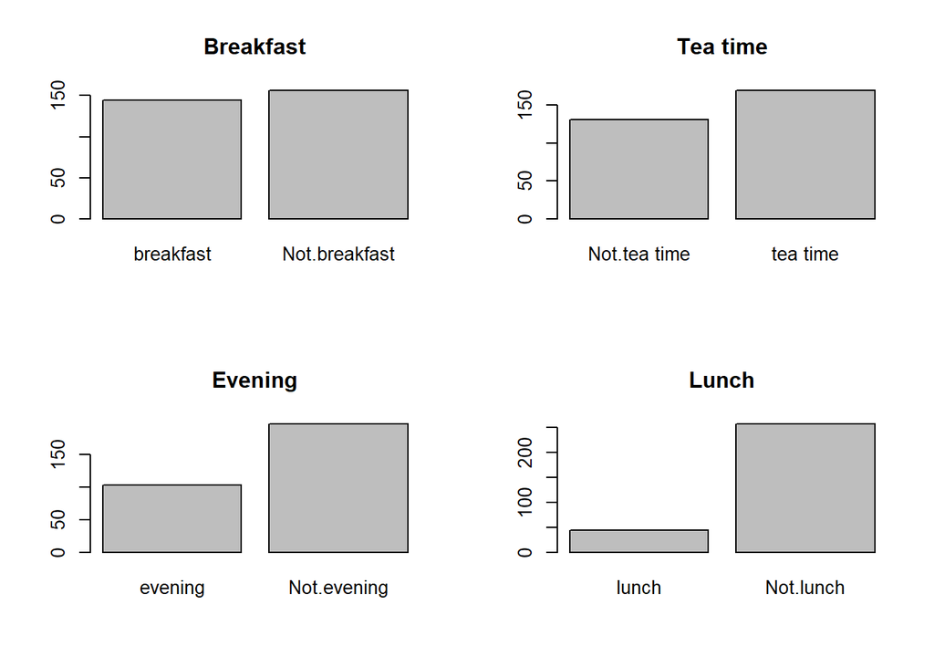

```r
counts1 <- table(tea$breakfast)
counts2 <- table(tea$tea.time)
counts3 <- table(tea$evening)
counts4 <- table(tea$lunch)
counts5 <- table(tea$dinner)
counts6 <- table(tea$always)
counts7 <- table(tea$tearoom)
counts8 <- table(tea$friends)
counts9 <- table(tea$resto)
counts10 <- table(tea$pub)
counts11 <- table(tea$Tea)
counts12 <- table(tea$How)
counts13 <- table(tea$sugar)
counts14 <- table(tea$how)
counts15 <- table(tea$where)
counts16 <- table(tea$price)
counts17 <- table(tea$age)
counts18 <- table(tea$sex)
counts19 <- table(tea$SPC)
counts20 <- table(tea$Sport)
counts21 <- table(tea$age_Q)
counts22 <- table(tea$frequency)
counts23 <- table(tea$escape.exoticism)
counts24 <- table(tea$spirituality)
counts25 <- table(tea$healthy)
counts26 <- table(tea$diuretic)
counts27 <- table(tea$friendliness)
counts28 <- table(tea$iron.absorption)
counts29 <- table(tea$feminine)
counts30 <- table(tea$sophisticated)
counts31 <- table(tea$slimming)
counts32 <- table(tea$exciting)
counts33 <- table(tea$relaxing)
counts34 <- table(tea$effect.on.health)
counts35 <- table(tea$home)
counts36 <- table(tea$work)

par(mfrow=c(2,2))
barplot(counts1, main="Breakfast")
barplot(counts2, main="Tea time")
barplot(counts3, main="Evening")
barplot(counts4, main="Lunch")
```

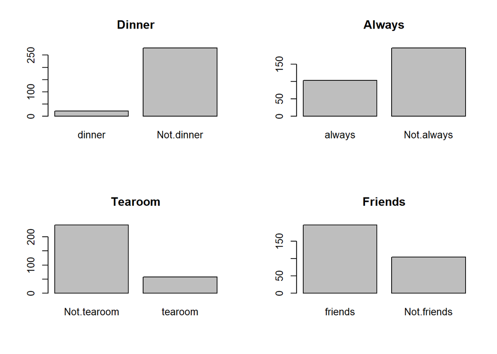

```r
barplot(counts5, main="Dinner")
barplot(counts6, main="Always")
barplot(counts7, main="Tearoom")
barplot(counts8, main="Friends")
```

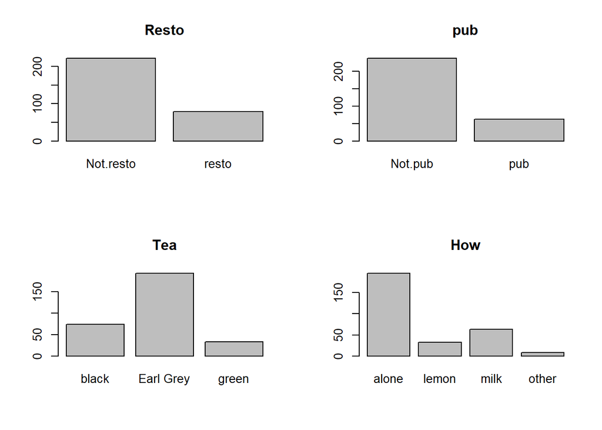

```r
barplot(counts9, main="Resto")
barplot(counts10, main="pub")
barplot(counts11, main="Tea")
barplot(counts12, main="How")
```

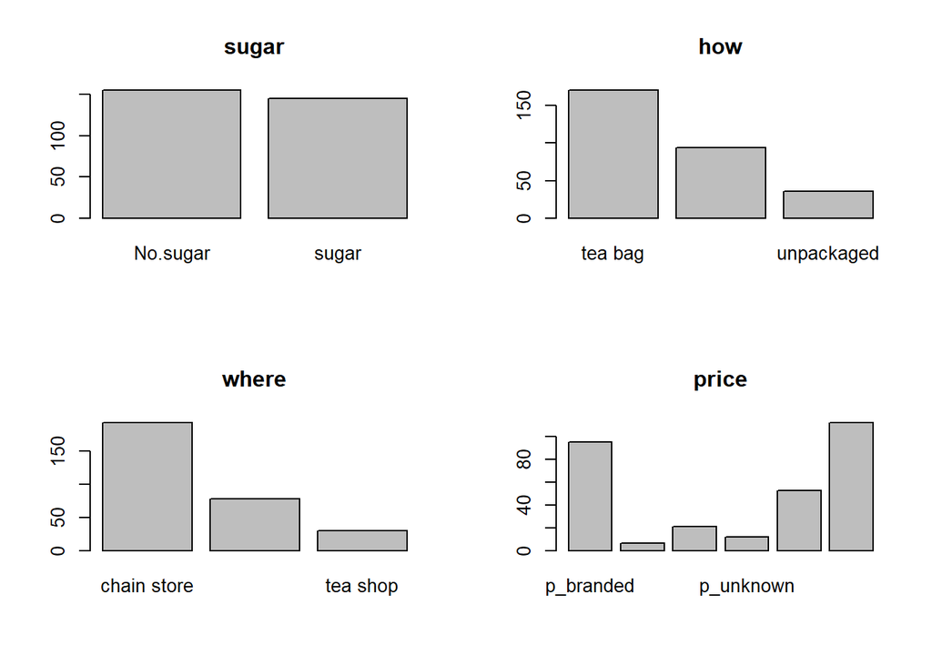

```r
barplot(counts13, main="sugar")
barplot(counts14, main="how")
barplot(counts15, main="where")
barplot(counts16, main="price")
```

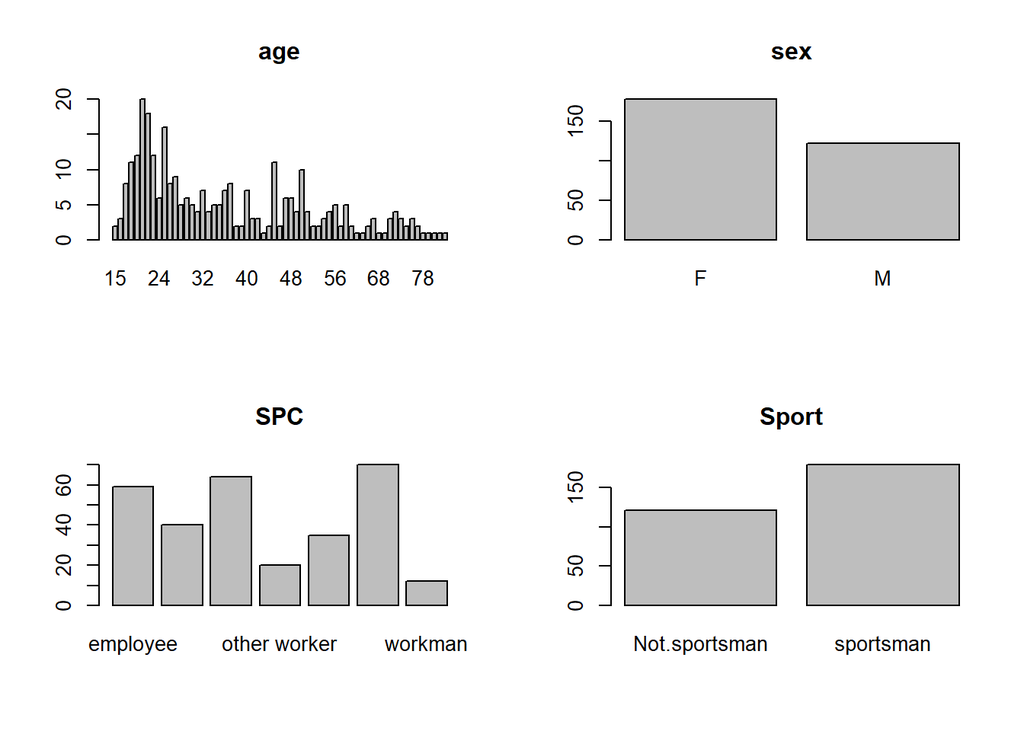

```r
barplot(counts17, main="age")
barplot(counts18, main="sex")
barplot(counts19, main="SPC")
barplot(counts20, main="Sport")
```

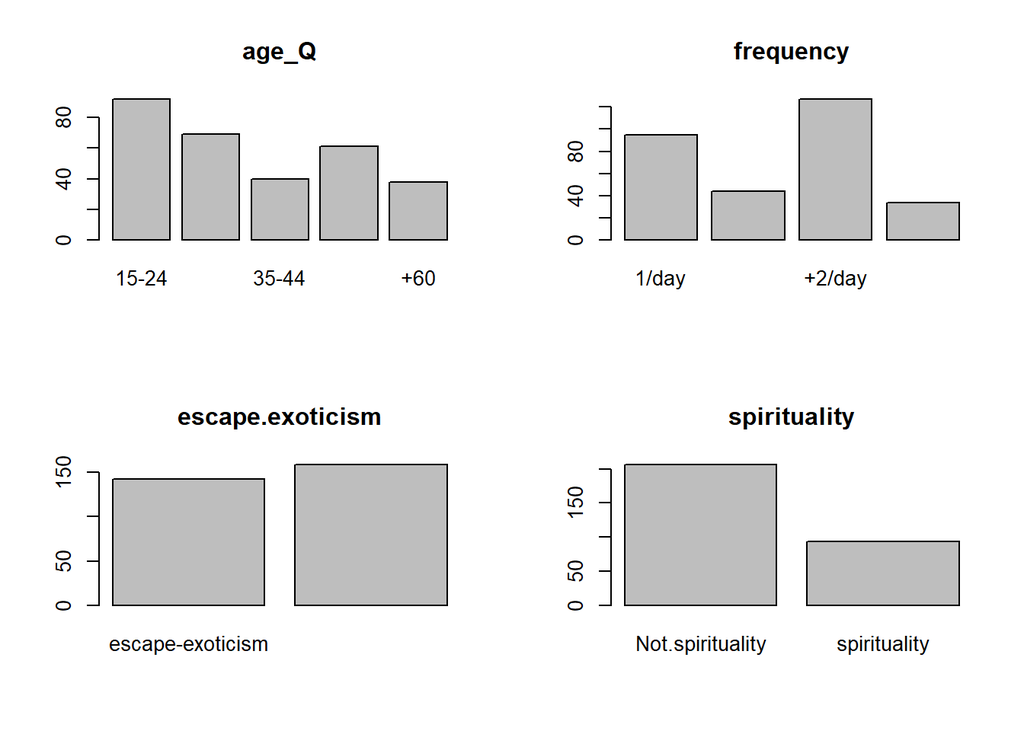

```r
barplot(counts21, main="age_Q")
barplot(counts22, main="frequency")
barplot(counts23, main="escape.exoticism")
barplot(counts24, main="spirituality")
```

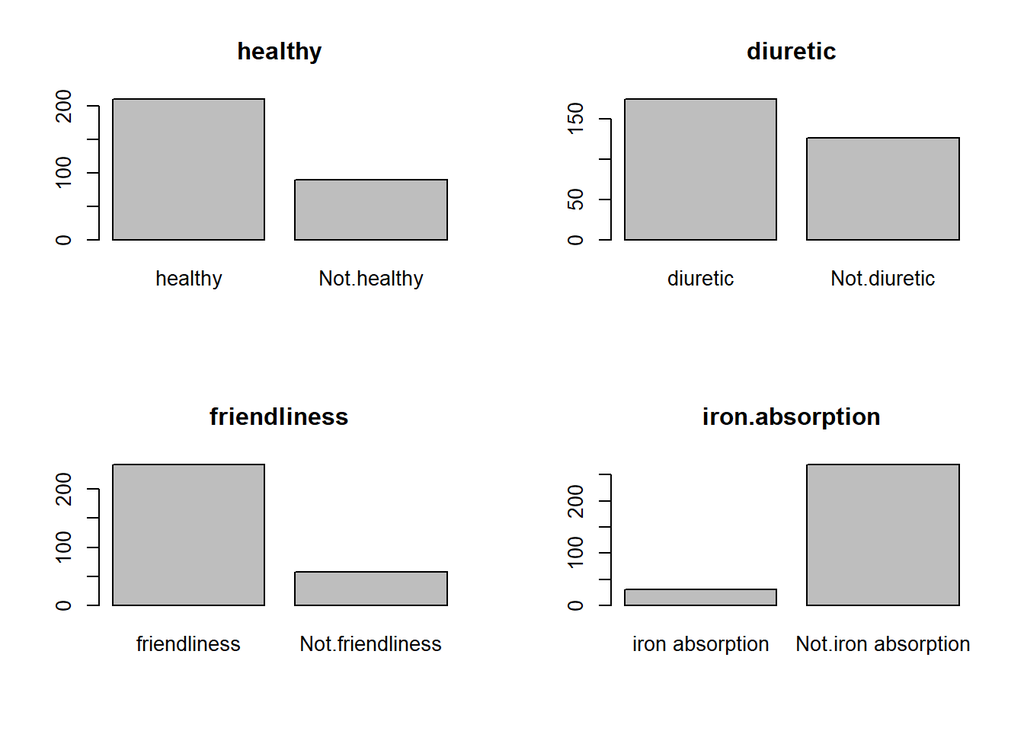

```r
barplot(counts25, main="healthy")
barplot(counts26, main="diuretic")
barplot(counts27, main="friendliness")
barplot(counts28, main="iron.absorption")
```

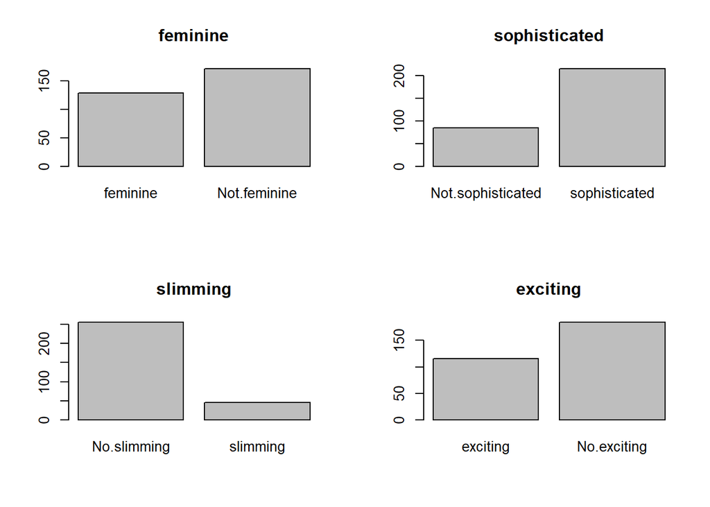

```r
barplot(counts29, main="feminine")
barplot(counts30, main="sophisticated")
barplot(counts31, main="slimming")
barplot(counts32, main="exciting")
```

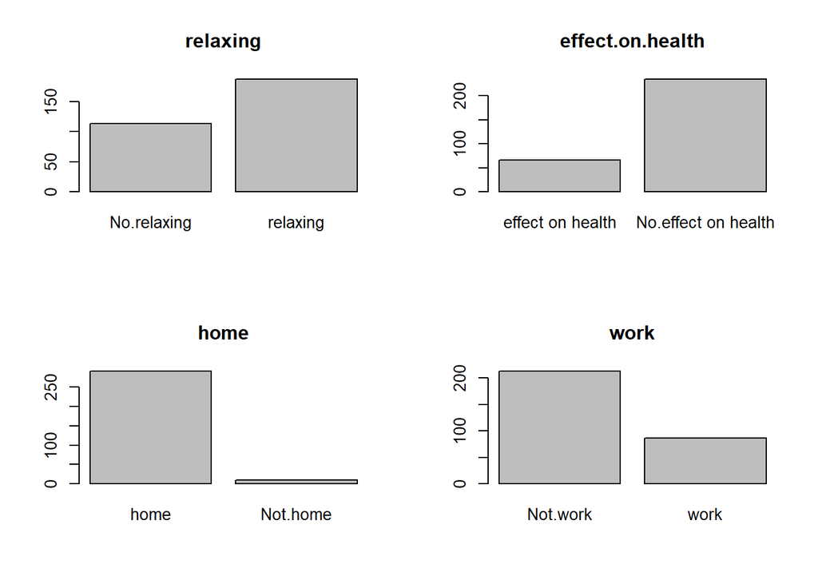

```r
barplot(counts33, main="relaxing")
barplot(counts34, main="effect.on.health")
barplot(counts35, main="home")
barplot(counts36, main="work")
```

```r
#Selecting the columns for the multiple correspondence analysis

keep_columns <- c("Tea", "How", "how", "sugar", "where", "tearoom", "healthy", "sophisticated", "relaxing")

# select the 'keep_columns' to create a new dataset
tea_time <- select(tea, one_of(keep_columns))

# look at the structure of the data
str(tea_time)
```

```
## 'data.frame':    300 obs. of  9 variables:
##  $ Tea          : Factor w/ 3 levels "black","Earl Grey",..: 1 1 2 2 2 2 2 1 2 1 ...
##  $ How          : Factor w/ 4 levels "alone","lemon",..: 1 3 1 1 1 1 1 3 3 1 ...
##  $ how          : Factor w/ 3 levels "tea bag","tea bag+unpackaged",..: 1 1 1 1 1 1 1 1 2 2 ...
##  $ sugar        : Factor w/ 2 levels "No.sugar","sugar": 2 1 1 2 1 1 1 1 1 1 ...
##  $ where        : Factor w/ 3 levels "chain store",..: 1 1 1 1 1 1 1 1 2 2 ...
##  $ tearoom      : Factor w/ 2 levels "Not.tearoom",..: 1 1 1 1 1 1 1 1 1 2 ...
##  $ healthy      : Factor w/ 2 levels "healthy","Not.healthy": 1 1 1 1 2 1 1 1 2 1 ...
##  $ sophisticated: Factor w/ 2 levels "Not.sophisticated",..: 1 1 1 2 1 1 1 2 2 1 ...
##  $ relaxing     : Factor w/ 2 levels "No.relaxing",..: 1 1 2 2 2 2 2 2 2 2 ...
```

```r
# multiple correspondence analysis
mca <- MCA(tea_time, graph = FALSE)

# summary of the model
summary(mca)
```

```
##
## Call:
## MCA(X = tea_time, graph = FALSE)
##
##
## Eigenvalues
##                        Dim.1   Dim.2   Dim.3   Dim.4   Dim.5   Dim.6   Dim.7
## Variance               0.211   0.184   0.148   0.132   0.125   0.120   0.109
## % of var.             13.586  11.831   9.491   8.506   8.026   7.736   7.005
## Cumulative % of var.  13.586  25.417  34.908  43.414  51.440  59.176  66.181
##                        Dim.8   Dim.9  Dim.10  Dim.11  Dim.12  Dim.13  Dim.14
## Variance               0.101   0.096   0.087   0.077   0.069   0.056   0.041
## % of var.              6.516   6.175   5.567   4.927   4.405   3.582   2.646
## Cumulative % of var.  72.697  78.873  84.439  89.366  93.772  97.354 100.000
##
## Individuals (the 10 first)
##                       Dim.1    ctr   cos2    Dim.2    ctr   cos2    Dim.3
## 1                  | -0.432  0.294  0.155 | -0.004  0.000  0.000 | -0.217
## 2                  | -0.314  0.155  0.064 | -0.123  0.028  0.010 | -0.502
## 3                  | -0.489  0.377  0.301 | -0.076  0.010  0.007 | -0.231
## 4                  | -0.471  0.350  0.388 |  0.033  0.002  0.002 |  0.023
## 5                  | -0.517  0.422  0.266 | -0.009  0.000  0.000 |  0.021
## 6                  | -0.489  0.377  0.301 | -0.076  0.010  0.007 | -0.231
## 7                  | -0.489  0.377  0.301 | -0.076  0.010  0.007 | -0.231
## 8                  | -0.208  0.068  0.036 | -0.053  0.005  0.002 | -0.657
## 9                  |  0.314  0.155  0.064 | -0.440  0.350  0.126 |  0.258
## 10                 |  0.723  0.825  0.272 | -0.627  0.711  0.204 | -0.363
##                       ctr   cos2
## 1                   0.107  0.039 |
## 2                   0.568  0.163 |
## 3                   0.120  0.067 |
## 4                   0.001  0.001 |
## 5                   0.001  0.000 |
## 6                   0.120  0.067 |
## 7                   0.120  0.067 |
## 8                   0.975  0.362 |
## 9                   0.151  0.043 |
## 10                  0.298  0.069 |
##
## Categories (the 10 first)
```

[output cut: 19 more lines]

```
## tea bag             -0.220 |  -0.151   0.975   0.030  -2.990 |
## tea bag+unpackaged  -7.706 |   0.202   0.965   0.019   2.362 |
## unpackaged          11.334 |   0.186   0.313   0.005   1.188 |
##
## Categorical variables (eta2)
##                      Dim.1 Dim.2 Dim.3
## Tea                | 0.065 0.130 0.371 |
## How                | 0.118 0.189 0.344 |
## how                | 0.566 0.515 0.030 |
## sugar              | 0.076 0.004 0.310 |
## where              | 0.619 0.663 0.081 |
## tearoom            | 0.369 0.062 0.000 |
## healthy            | 0.003 0.014 0.160 |
## sophisticated      | 0.079 0.062 0.011 |
## relaxing           | 0.008 0.018 0.022 |
```

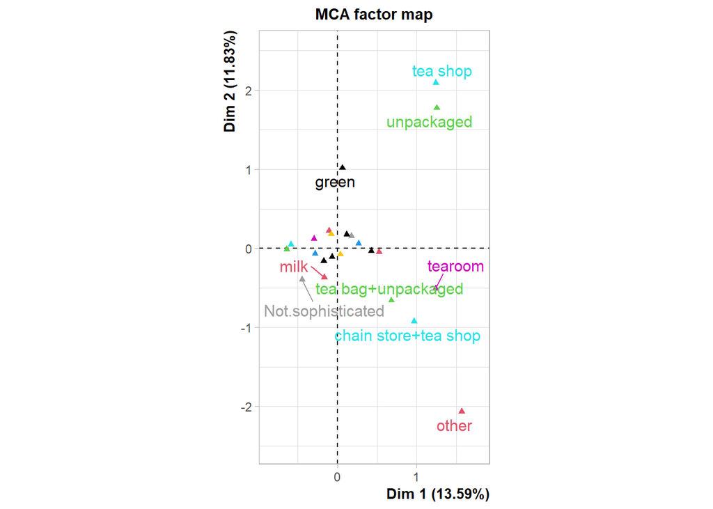

```r
# visualize MCA
plot(mca, invisible=c("ind"), habillage = "quali")
```

The multiple correspondence analysis on the selected columns of the tea data results in 14 dimensions, which together explain 100% variance of the data. The first dimension explains 13.6% of the variance and the second dimension 11.8%, and together these two dimensions explain 25.4% of the variance of the data.